# exam_3

James Hutt

## Question 1: Exploratory Data Analysis

1A) I hypothesise that the correlation coefficient between number of migrants and amount of money they send home will be positive. I expect the relationship to be significant and relatively large as I suspect that each migrant sends a relatively similar amount of money home and so the variation in total amount of money sent home will largely be explained by number of migrants. We should control for age and gender of migrants, given different earning power. We may also wish to control for time spent in receiving country, which may well be significant.

1B)

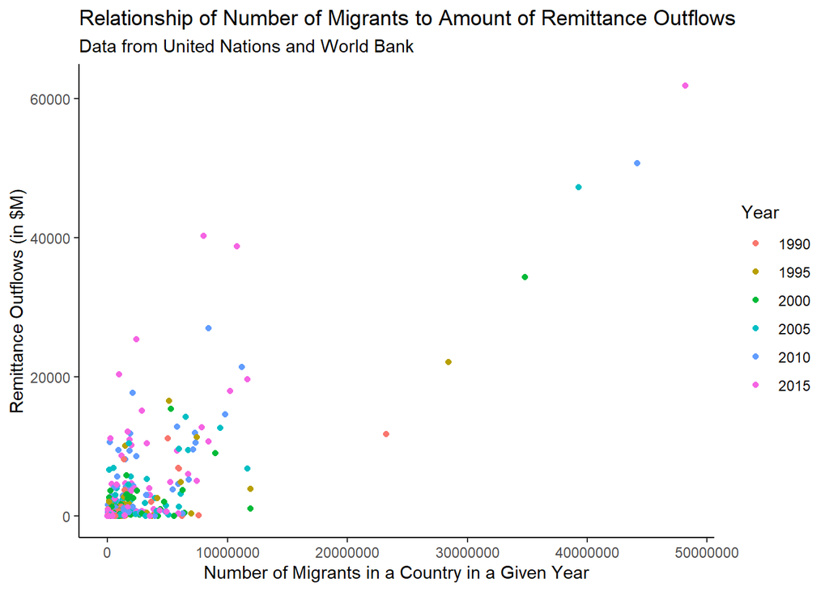

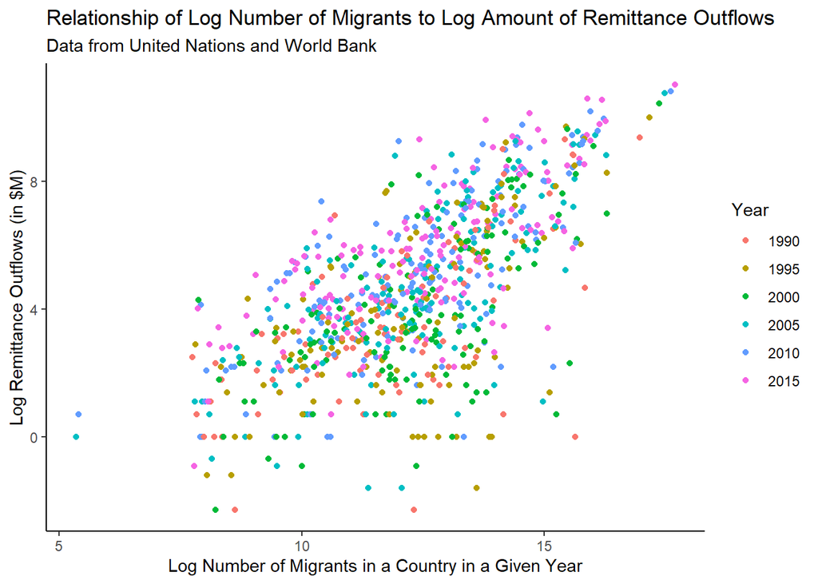

1C)

Correlation Coefficient between log migrants and log remittances over time

Data from United Nations and World Bank

| Year | Correlation Coefficient |
| --- | --- |
| 1990 | 0.6520407 |
| 1995 | 0.5717538 |
| 2000 | 0.6238396 |
| 2005 | 0.7004822 |
| 2010 | 0.7189968 |
| 2015 | 0.7250154 |

As expected the coefficient is positive. We can not tell yet at what level it is significant but visually the trend looks quite strong. In 2015, the correlation was 72%, a strong positive linear relationship.

## Question 2: Running and Interpreting Regressions

2A)

Effect of Number of Migrants on Amount of Remittances

Both IV and DV are logged

| Variable | Estimate | Lower bound | Upper bound |
| --- | --- | --- | --- |
| (Intercept) | −5.63 | −6.44 | −4.83 |
| log_migrants | 0.84 | 0.77 | 0.90 |

2B) The average treatment effect of more migrants is best expressed in percentage terms, the elasticity. A 1% increase in the number of migrants in the country is associated with an 0.84% increase in remittances sent from the country. This is the ATE of more migrants. Given the confidence intervals of 0.77 and a 0.90 the Bayseian would be 95% sure that the true value of the elasticity lies within this range, whilst a frequentist who ran this experiment a large number of times would expect the observe elasticity to be within this range 95% of the time.

2C)

Calculate fitted value:
$$ln(remittances) = -5.63 + 0.84 * ln(migrants)$$

$$ln(remittances) = -5.62 + 0.84 * 17.69 = 9.23$$
We can get the same result from the predict function, with the difference due to rounding:

```r
# store as variable to report in Rmd.

q2c <- predict(log_log_model, newdata = tibble(log_migrants = 17.69))
```

Fitted value using predict function is 9.15.

## Question 3: Multivariate regression

3A)

Effect of Number of Migrants on Amount of Remittances

Both IV and DV are logged

| Variable | Estimate | Lower bound | Upper bound |
| --- | --- | --- | --- |
| (Intercept) | −3.98 | −5.77 | −2.19 |
| log_migrants | 0.62 | 0.47 | 0.76 |
| continentAmericas | −2.45 | −4.89 | −0.02 |
| continentAsia | 1.03 | −1.62 | 3.68 |
| continentEurope | −2.57 | −5.29 | 0.14 |
| continentOceania | −0.06 | −2.59 | 2.46 |
| log_migrants:continentAmericas | 0.29 | 0.08 | 0.49 |
| log_migrants:continentAsia | 0.05 | −0.16 | 0.26 |
| log_migrants:continentEurope | 0.33 | 0.12 | 0.55 |
| log_migrants:continentOceania | 0.13 | −0.10 | 0.36 |

3B) We first must note that the omitted catory (continent) is Africa. Thus, the estimates of the intercept and log_migrants coefficients are the regression coefficients for Africa. That is, in Africa:

$$ln(remittances) = -3.98 + 0.62 * ln(migrants)$$

The coefficient continentAmericas is the adjustment to the intercept which we must make when America = 1, that is, in America rather than in Africa. Similarly, the interaction coefficient log_migrants:continentAmericas is the adjustment to the gradient (which we are interpreting as the elasticity) for Americas, relative to the Africa value.

In the Americas:

$$ln(remittances) = -3.98 - 2.45 + (0.62 + 0.29) * ln(migrants)$$

$$ln(remittances) = -6.43 + 0.91 * ln(migrants)$$

With the same interpretation as before, we can say that a 1% increase in migrants present in an American country is associated with a 0.91% increase in remittances from that country.

## Question 4: Running many regressions

Effect of Number of Migrants on Amount of Remittances over Time

Both IV and DV are logged

| Year | Estimated Coefficient | 95% CI Lower bound | 95% CI Upper bound |
| --- | --- | --- | --- |
| 1990 | 0.76 | 0.59 | 0.94 |
| 1995 | 0.76 | 0.56 | 0.96 |
| 2000 | 0.81 | 0.64 | 0.99 |
| 2005 | 0.87 | 0.73 | 1.02 |
| 2010 | 0.86 | 0.73 | 0.98 |
| 2015 | 0.80 | 0.68 | 0.92 |